# Case Study 2: How can a wellness company play it smart?

Dylan Attlesey

2022-05-30

## Data and Limitations

In most data tables of this data set, there are 33 subjects. This is considered sufficient, if just barely, for statistical analysis.

```r
print(n_distinct(heartrate_seconds$Id))
```

```
## [1] 14
```

```r
print(n_distinct(sleepDay$Id))
```

```
## [1] 24
```

```r
print(n_distinct(weightLogInfo$Id))
```

```
## [1] 8
```

The exceptions to this, as seen above, are heart rate, sleep, and weight measurements.

33 is not far clear of 30, and results from any data set with so few subjects is liable to scrutiny. This is seriously exacerbated by several layers of response bias. The first arises as result of the use of Amazon’s Mechanical Turk platform to collect data, the users of which are no doubt unreflective of the general population. The second is due to the fact that, of Mechanical Turk participants, only those who already own and choose to wear a fitness tracker provide responses.

## Cleaning and Manipulation

The majority of the analyses performed here were temporal. As such, it was necessary to convert the dates of records to a more convenient data type, chron, which supports an intuitive arithmetic. Neither spreadsheet software nor the provided ‘chron()’ conversion function was capable of converting the provided strings, so a custom function was written to split, trim, convert, and recombine the date, and time as chron:

```r
fixAMPM <- function(datetimes){ #takes a column of format dd/mm/yy hh:mm:ss (A/P)M
  datetimes_split <- as_tibble_col(datetimes, column_name = "ActivityTime")
  datetimes_split <- as_tibble(str_split_fixed(datetimes_split$ActivityTime, " ", 3))
  colnames(datetimes_split) <- c("split_date", "split_time", "AmOrPm")
  datetimes_split <- mutate(datetimes_split, split_date = chron(split_date, split_time))
  datetimes_split <- mutate(datetimes_split, clean_time = chron(ifelse((datetimes_split$AmOrPm == "PM" & datetimes_split$split_time != "12:00:00"), datetimes_split$split_date + 1/2, datetimes_split$split_date)))
  datetimes_split <- mutate(datetimes_split, clean_time = chron(ifelse((datetimes_split$AmOrPm == "AM" & datetimes_split$split_time == "12:00:00"), datetimes_split$clean_time -1/2, datetimes_split$clean_time)))
  return(datetimes_split[,"clean_time"])
}
```

The fixAMPM() function generates and returns a vector of ‘chron’ objects corresponding to the date and time strings provided in the data. The fixAMPM() function is then called by the add_chron() function, which binds the returned vector to the relevant dataset as the ‘clean_time’ column.

```r
add_chron <- function(df, time_column){
  return(bind_cols(df, fixAMPM(time_column)))
}
```

## Analysis

### Activity levels

The vast majority of subjects’ recorded time, just above 81%, was spent sedentary.

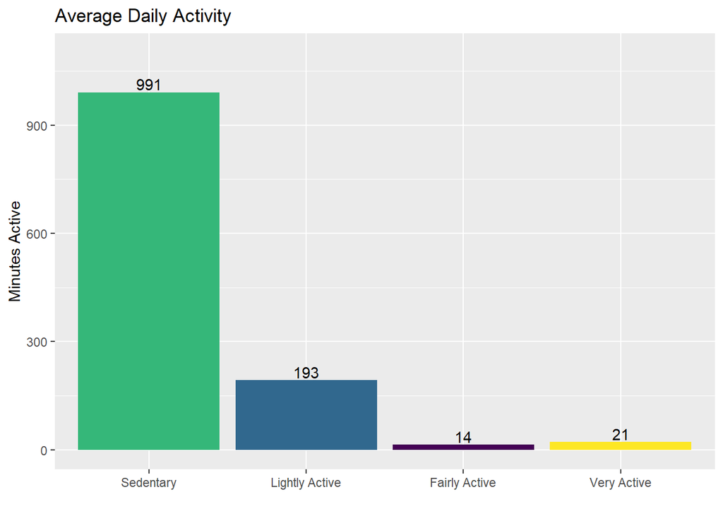

The least amount of time is spent fairly active. This may present an opportunity: users who may be too overweight or otherwise unable to safely reach the very active intensity level might be encouraged to explore activities that fall in the fairly active range. This could be achieved by infographics, wellness guides, or notifications.

According to CDC [recommendations](https://www.cdc.gov/physicalactivity/basics/adults/index.htm), adults between the ages of 18 and 64 should achieve at least 75 minutes of vigorous physical activity per week. By this data, users spend an average 147 minutes a week very active, almost double the CDC’s recommended minimum for aerobic physical activity. This is significantly higher than the [American average](https://www.psu.edu/news/research/story/americans-fall-short-federal-exercise-recommendations) of 17 minutes per week.

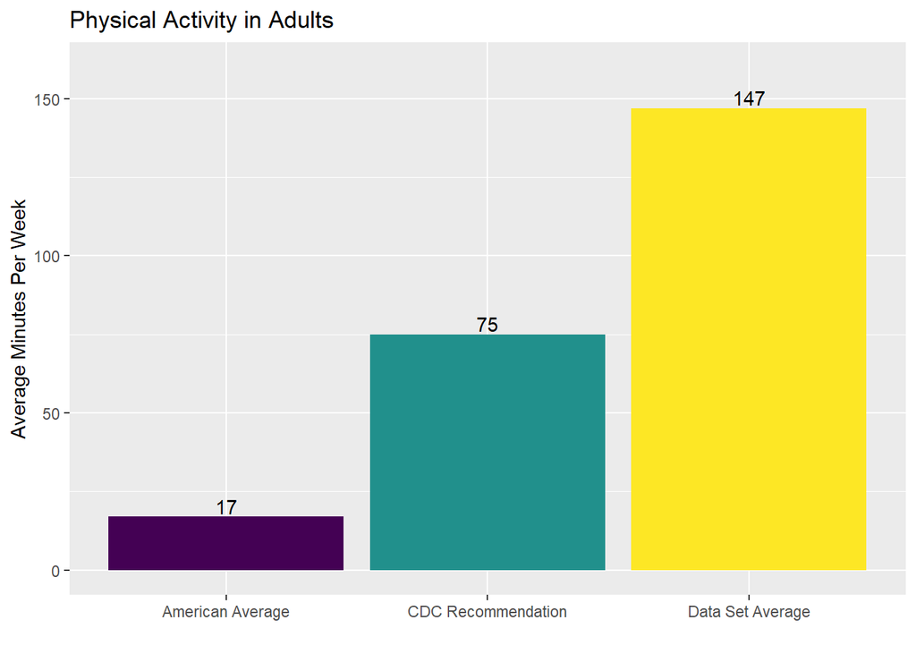

Clearly, subjects were not average Americans. This suggests that those most likely to use these fitness trackers are already more active than average Americans. With Bellabeat’s low market saturation, it is our recommendation that Bellabeat tailor marketing to reach previously physically active segments of the population.

### Trends and Outliers

To calculate changes over time, rows in the daily intensities data frame were grouped by day. Then these groups were summarised, finding the average amount of time spent sedentary, lightly active, fairly active, and very active across subjects.

Initial analysis indicates that users may experience a small drop in time spent active while using their fitness tracker. While an increase, a decrease, and no change are all within the margin of error, this analysis suggests a decrease is more likely. This wouldn’t necessarily be surprising; users may initially be motivated to exercise when they start using their tracker, and then lose motivation over time.

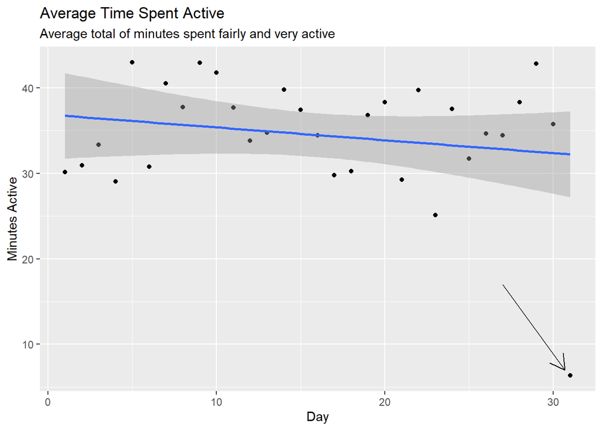

However, the day 31 average, indicated by the arrow, is a significant outlier, possibly because the final day of measurements was cut short. We can find evidence of this by looking at the average total number of minutes recorded per day.

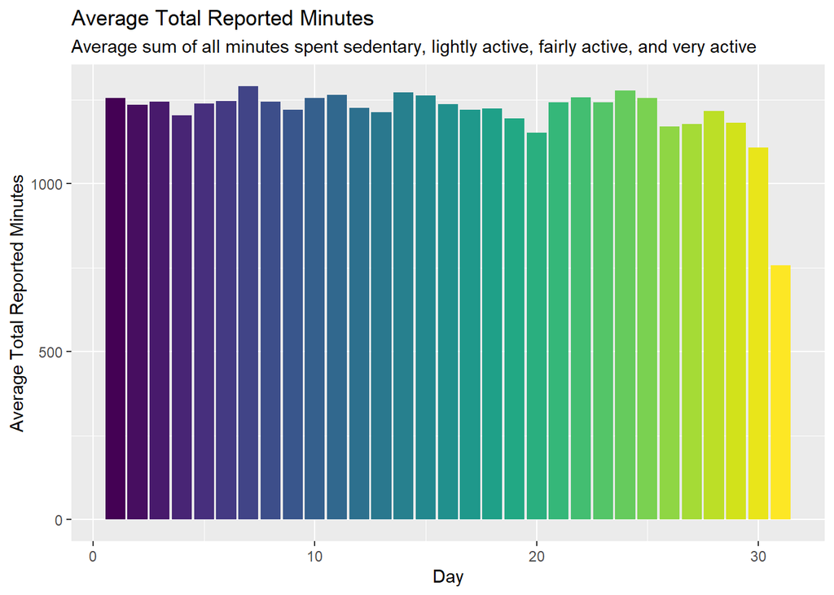

We do in fact see that it is fairly consistent until the last day, at which time we see an anomalous measurement.

Removing it, we find that daily time spent fairly or very active remains stable over the time of the study, with either a very mild positive or negative trend possible with the margin of error, with a positive trend being slightly more likely than a negative now.

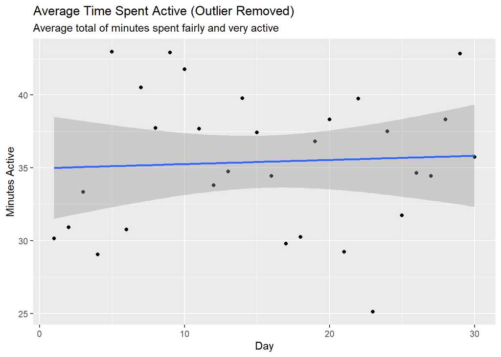

We may perform a similar analysis on time spent sedentary. After removing the anomalous day 31 data, we find a downward trend in the number of minutes spent sedentary per day.

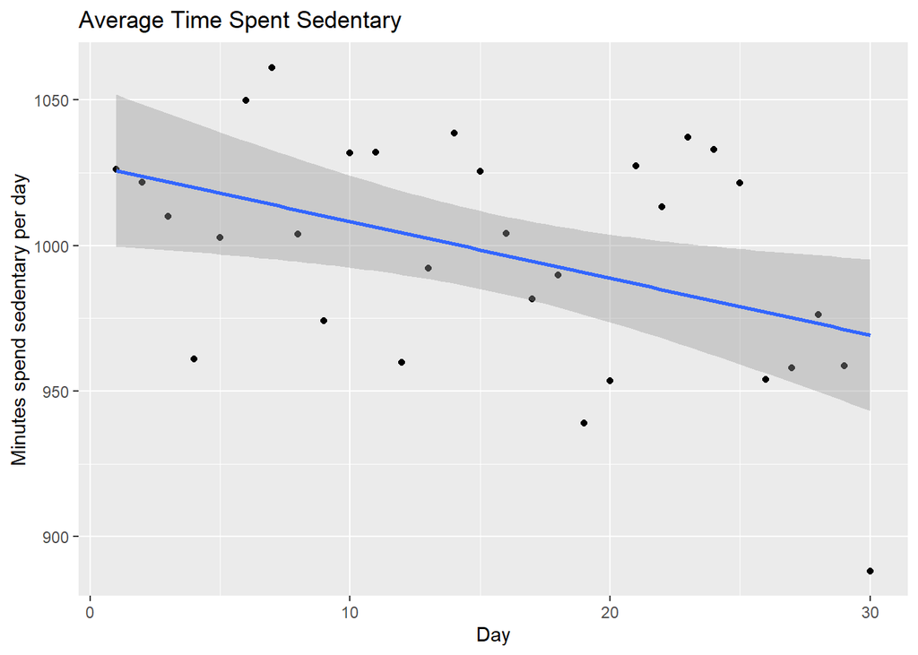

### Resting Heart Rate

This dataset provides heart rate measurements updated every 5 seconds. Averaging these results over each minute, we’re able to compare minute-to-minute data for heart rate, sleep, and the intensity of physical activity by using dplyr’s inner_join() function. Sleep measurements are updated every minute at the 30 second mark, so these values were simply truncated to the minute. Resting heart rate is the average heart rate one experiences when not engaged in physical activity and not sleeping, so it is necessary to filter out minutes in which the subject was asleep or engaged in physical activity (3-6 on intensity scale). we are left with “rest minutes” on which we can perform analysis.

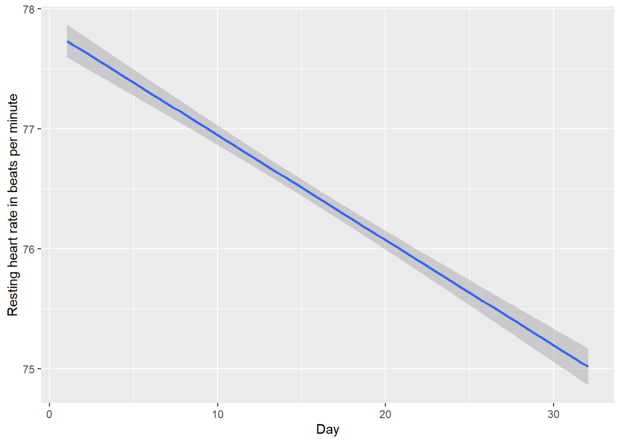

We see that our data indicates that users may see a drop in resting heart rate. Unfortunately, this is only an indicator and should not be taken as fact; only twelve subjects were common across the sleep, heart rate, and physical intensity data sets. This clearly falls short of the threshold of 30 necessary for most statistical analyses. A lower resting heart rate is closely associated with many positive health outcomes, which would allow for claims about improved health to be made in marketing, but that would require a larger data set with more subjects. As it is, this is only an indicator for further study.

### Modeling Calories Burned

```
##
## Call:
## lm(formula = Calories ~ SedentaryMinutes + FairlyActiveMinutes +
##     LightlyActiveMinutes + VeryActiveMinutes, data = dailyActivity)
##
## Residuals:
##      Min       1Q   Median       3Q      Max
## -1896.98  -403.77   -58.61   374.89  2650.55
##
## Coefficients:
##                       Estimate Std. Error t value Pr(>|t|)
## (Intercept)          1.241e+03  8.934e+01  13.891  < 2e-16 ***
## SedentaryMinutes     3.539e-01  6.486e-02   5.457 6.22e-08 ***
## FairlyActiveMinutes  3.676e+00  9.231e-01   3.982 7.36e-05 ***
## LightlyActiveMinutes 2.010e+00  1.750e-01  11.490  < 2e-16 ***
## VeryActiveMinutes    1.295e+01  5.526e-01  23.442  < 2e-16 ***
## ---
## Signif. codes:  0 '***' 0.001 '**' 0.01 '*' 0.05 '.' 0.1 ' ' 1
##
## Residual standard error: 525.4 on 935 degrees of freedom
## Multiple R-squared:  0.467,  Adjusted R-squared:  0.4648
## F-statistic: 204.8 on 4 and 935 DF,  p-value: < 2.2e-16
```

Above, we see a few key values. Coefficients tell us how closely the independent variables (the number of minutes spent at each level of physical intensity) is correlated with the dependent variable (the number of calories burned). Here the estimated coefficient for VeryActiveMinutes is 12.95. This means that for each marginal increase of one minute spend very active, we expect to see a marginal loss of 12.95 calories. This can be contrasted with the other coefficients, for example 2.01 for LightlyActiveMinutes. Together, these show that for each marginal unit of increased time, we expect to see six more times the benefit of calories burned from very active time, as opposed to lightly active time.

The standard error gives an average distance, across all data points, from the mean. The R-squared statistics give an approximation for how much of the variance in the data the model can explain. Here, a value of .46 implies that the model can only account for 46% of the variance in calories burned, and that other significant factors must be at play.

### Weight Measurements

Weight loss, as a statistic, would be very useful for marketing. Statistically verifiable weight loss trends would allow advertisements to make claims about weight loss, which is enticing to large sections of the population. Unfortunately, the weight measurements in this set are not reliable.

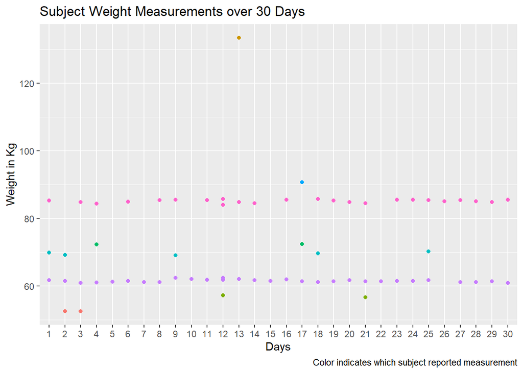

## Recommendations

In summary, it is the recommendation of this researcher that, based on evidence provided above, that Bellabeat

- aim marketing and advertisement at women who are already physically active,
- use notifications and other methods to recommend exercises that fall in the ‘fairly active’ range of intensities,
- collect data over a longer time-span to determine if Bellabeat users see a drop in weight over time, and
- collect data from more individuals’ sleep, activity intensity levels, and heart rates.

## References

*Furberg, R., Brinton, J., Keating, M., & Ortiz, A. (2016). Crowd-sourced Fitbit datasets 03.12.2016-05.12.2016 [Data set]. Zenodo. https://doi.org/10.5281/zenodo.53894

*U.S. Department of Health and Human Services. (2018). Physical Activity Guidelines for Americans, 2nd edition. Retrieved from https://health.gov/paguidelines/second-edition/pdf/Physical_Activity_Guidelines_2nd_edition.pdf